# Липецк - 2023

# Липецк - 2023

Балаш В.А., Мельничук Д.В.

*Алгоритмы выделения и представления тем в корпусе текстов при исследовании советского прошлого*

Всероссийская очная научно-практическая конференция «Советское прошлое и современное российское общество: культурные концепты, актуальные практики, социальные эффекты»

Работа выполнена при финансовой поддержке РНФ.

грант № 22-18-00153

# Выделение и представление тем в корпусе текстов

Исходные данные:

- веб-архив публикаций издательства “Коммерсант” за 1992 - 2023 годы;
- публикации затрагивающие “советский период” выбирались с помощью сервиса сайта https://www.kommersant.ru/search;
- критерий поиска: в тексте публикации одновременно упоминались термины “ссср” и “советский”;

# Выделение и представление тем в корпусе текстов

Задачи:

- разработать скрипт для автоматической загрузки текстов статей с сайта издательства;
- выполнить предварительную обработку текстов;
- сформировать корпус текстов, отобрав фрагменты относящиеся к периоду СССР (тексты полностью либо частично);
- разделить корпус текстов на кластеры (темы) сходные между собой;
- провести группировку тем;
- выделить и представить наиболее информативные слова (термины), характеризующие каждую из тем;
- проанализировать динамику представления тем;
- экспортировать выборку статей для выбранных тем;

# Выделение и представление тем в корпусе текстов

Используемые программные средства:

- beautifulsoup4, spacy,pymorphy2, nltk (python)
- tm,tidytext (R)
- BERTopic (https://maartengr.github.io/BERTopic/index.html)

# Число статей и слов

Всего статей: 20175, слов: 26.243.554, упоминаний “ссср”, “совестк..”: 118177.

Наиболее частые варианты

| word | n |
| --- | --- |
| ссср | 51877 |
| советского | 12267 |
| советской | 11151 |
| советских | 10181 |
| советские | 6928 |
| советский | 6863 |
| советское | 3611 |
| советская | 3475 |
| советским | 3214 |
| советском | 2696 |
| советскую | 1759 |
| советскому | 1619 |
| советскими | 1312 |
| советско | 931 |
| советски | 141 |

# Издания

Количество статей в корпусе текстов в разрезе изданий (первые 20)

| issue | N |
| --- | --- |
| Газета «Коммерсантъ» | 14526 |
| Журнал “Коммерсантъ Власть” | 5237 |
| Журнал “Огонёк” | 4014 |
| NA | 2882 |
| Журнал “Коммерсантъ Деньги” | 1801 |
| Газета «Коммерсантъ» /П | 831 |
| Журнал “Огонёк” | 633 |
| Журнал «Коммерсантъ Weekend» | 603 |
| Weekend | 577 |
| Газета “Коммерсантъ С-Петербург” | 438 |
| Радио «Ъ FM» | 354 |
| Коммерсантъ История | 265 |
| Мир | 231 |
| Общество | 216 |
| Автопилот | 199 |
| Наука | 176 |
| Некрологи | 151 |
| Журнал “Коммерсантъ Секрет Фирмы” | 131 |
| Журнал “Коммерсантъ Власть” | 119 |
| Материалы сайта | 111 |

# Группировка статей по числу упоминаний тэгов “ссср”, “совестк..”

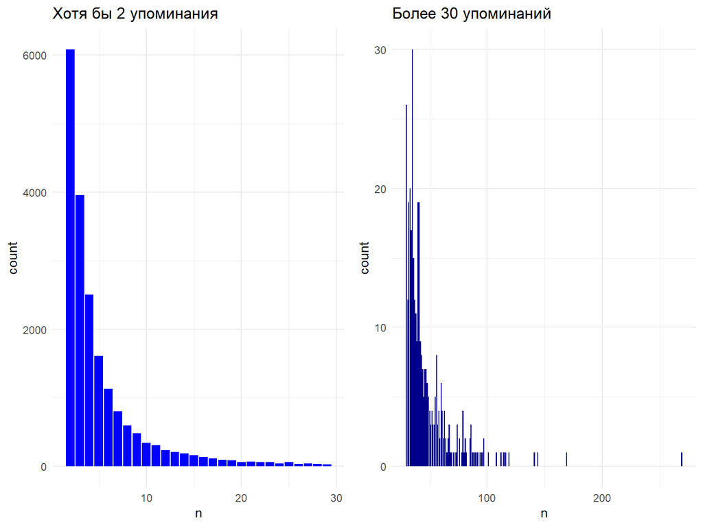

# Исторические периоды. Число вхождений в текстах четырехзначных чисел (годов?) (1918 : 1989)

Четырехзначные числа в приведенном диапазоне встречались примерно в половине текстов

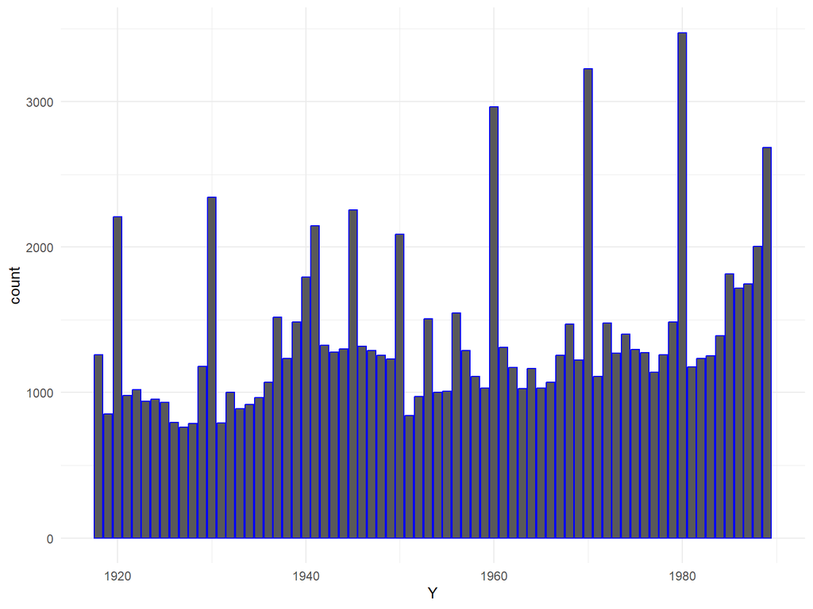

# Исторические периоды. Число вхождений в текстах четырехзначных чисел (годов?) (1918 : 1989)

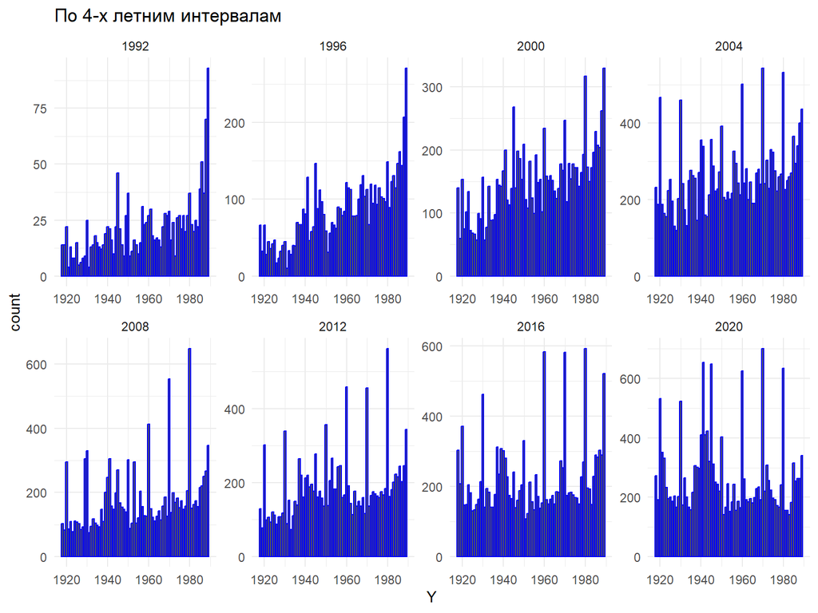

# Выбор информативных текстов (фрагментов)

Каковы могут быть критерия отбора текстов (информативной части текстов)?

- упоминание выбранных тэгов (число упоминаний)
- возможная ссылка на годы советского периода (1918 - 1989)
- эвристическое правило
- экспертно
- …

Не все тексты с большим числом упоминаний являются информативными. Например, в их число попадают справочники с краткими сведениями о депутатах Думы, биографическе статьи, некрологи и т.п.

Вероятно экспертный выбор - наиболее надежный. Если бы часть текстов удалось разметить экспертно, то появилась бы возможность строить более точные решающие правила.

# Выбор информативных текстов (фрагментов)

Далее представлены результаты с использованием эвристического правила.

Корпус текстов формировался следующим образом:

- тексты лематизировались
- находились вхождения тэгов “ссср”, “советский”
- выделялись фрагменты K=40 слов до и после тэга
- выделялись 5 предложений (по 2 предложения до и после тэга, если предложения длинные)
- если в статье выделялось несколько фрагментов, они объединялись в один документ

Для тематического моделирования по сформированному корпусу текстов использовался пакет BERTopic

# Векторизация документов и выделение тем (кластеризация)

BERTopic: Выделено 164 темы. Критерий остановки - число документов в теме не менее 10.

Отнесено к одной из тем около 60% документов.

Примерно 40% процентов документов не удалось классифицировать (численность кластера оказалась меньше 10 документов)

| Topic | Top_n_words | n |
| --- | --- | --- |
| 0 | сборная, команда, чемпионат, матч, тренер, олимпийский, олимпиада, игра, спорт, динамо | 769 |
| 1 | фильм, режиссёр, кино, роль, картина, снять, советский, не, на, из | 711 |
| 2 | книга, писатель, литература, автор, роман, не, советский, его, он, это | 452 |
| 3 | искусство, выставка, художник, музей, галерея, коллекция, живопись, картина, художественный, русский | 441 |
| 4 | самолёт, аэрофлот, воздушный, авиация, полёт, авиакомпания, лётчик, пилот, истребитель, авиационный | 290 |
| 5 | 00, 10, 15, 20, 30, режиссёр, 45, 19, сериал, роль | 246 |
| 6 | песня, музыка, рок, концерт, музыкант, альбом, музыкальный, композитор, оркестр, группа | 234 |
| 7 | космический, луна, космос, космонавт, полёт, спутник, лунный, станция, орбита, корабль | 217 |
| 8 | автомобиль, машина, газ, автомобильный, завод, производство, форд, модель, легковой, на | 201 |
| 9 | нефть, нефтяной, месторождение, газ, цена, компания, газпром, добыча, газовый, экспорт | 189 |

# Интерпретация тем

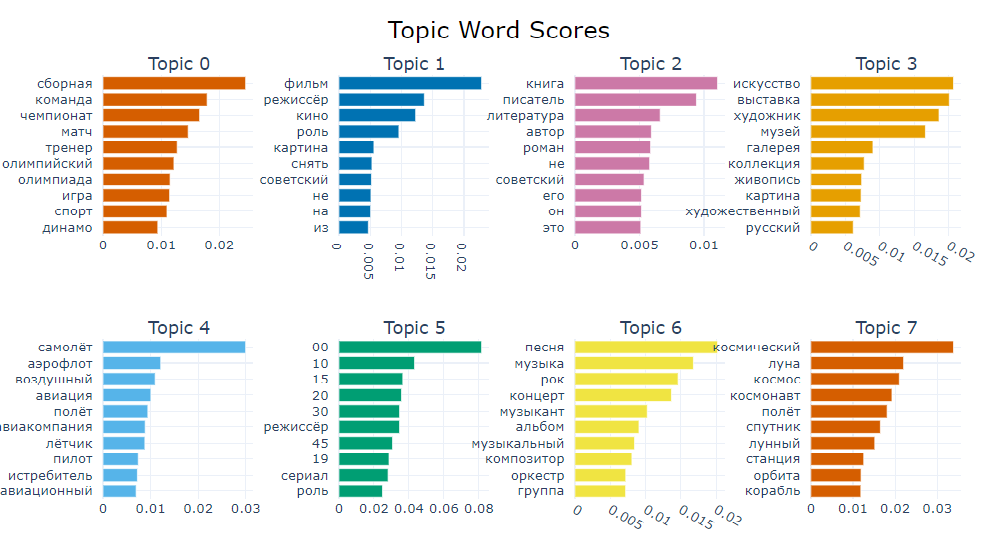

# Интерпретация тем

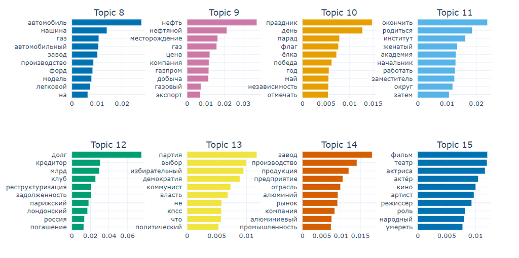

# Возможности группировки тем

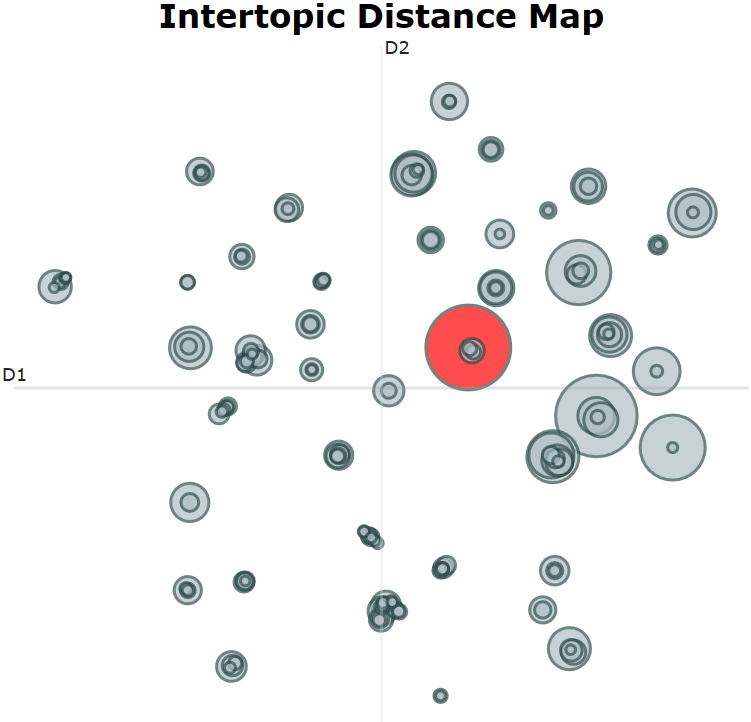

# Планы на будущее?

- Динамическое тематическое моделирование (изменение состава тем и ключевых слов для описания отдельных тем во времени)
- Улучшение агоритмов отбора текстов (фрагментов текстов)
- Выделение наиболее типичных фраз внутри тем
- Суммаризация текстов для выбранной темы
- …

# Спасибо за внимание